# Practical Machine Learning Course Project

# Summary

Using devices such as Jawbone Up, Nike FuelBand, and Fitbit it is now possible to collect a large amount of data about personal activity relatively inexpensively. These type of devices are part of the quantified self movement â€“ a group of enthusiasts who take measurements about themselves regularly to improve their health, to find patterns in their behavior, or because they are tech geeks. One thing that people regularly do is quantify how much of a particular activity they do, but they rarely quantify how well they do it. In this project, the goal is to use data from accelerometers on the belt, forearm, arm, and dumbell of 6 participants to predict the manner in which they did the exercise.

The data for this project come from this source: http://groupware.les.inf.puc-rio.br/har.

### Libraries

The following libraries were used throughout the code.

```r
library(caret)
library(e1071)
library(randomForest)
```

### Loading and preprocessing the data

```r
download.file("https://d396qusza40orc.cloudfront.net/predmachlearn/pml-training.csv", "pml-training.csv")
download.file("https://d396qusza40orc.cloudfront.net/predmachlearn/pml-training.csv", "pml-training.csv")
pmldata <- read.csv("pml-training.csv")
pmltest <- read.csv("pml-testing.csv")

# replace NA with 0 to make things easy in modelings and predictions as there are a lot of NAs in the data set
pmldata[is.na(pmldata)] <- 0
pmltest[is.na(pmltest)] <- 0
```

Use cross validation, the data set was split up into training and cross validation sets in a 3:1 ratio in order to train the model and then test it against the remaining 25% data.

```r
set.seed(34525)
trIdx <- createDataPartition(pmldata$classe, p = 3/4, list = FALSE)
train <- pmldata[trIdx,]
val <- pmldata[-trIdx,]
```

```r
train <- subset(train, select=c(roll_belt:classe))
val <- subset(val, select=c(roll_belt:classe))
test <- subset(pmltest, select=c(roll_belt:magnet_forearm_z))
```

Use pca preprocessing.

```r
prepro <- preProcess(train[,-length(train)], method = "pca", thresh = 0.9)
prepro
```

[output not shown]

Reduce the number of predictors.

```r
reducedFeatures <- predict(prepro, train[,-length(train)])
reducedTr <- data.frame(reducedFeatures, classe = train$classe)
pcatr <- subset(reducedTr, select = c(PC1:PC34, classe))
```

### Building a model

This is a typical multi classfication problem rather than a regression problem. After investigation, I decided to try the two polular classifiers. One is svm, the other is random forest. The first model I trained is a svm classifier with RBF kernel.

```r
fitsvm <- svm(classe~., data = pcatr)
```

Test it on validation set

```r
#use PCA on validation set just as we did in training set
reducedVal <- predict(prepro, val[,-length(val)])
pcaVal <- subset(reducedVal, select = c(PC1:PC34))
```

```r
confusionMatrix(predict(fitsvm, pcaVal), val$classe)
```

```
## Confusion Matrix and Statistics
##
##           Reference
## Prediction    A    B    C    D    E
##          A 1295   92   42   28    9
##          B   22  751   57   23   18
##          C   34   91  720   75   53
##          D   34   10   33  678   33
##          E   10    5    3    0  788
##
## Overall Statistics
##
##                Accuracy : 0.863
##                  95% CI : (0.853, 0.8725)
##     No Information Rate : 0.2845
##     P-Value [Acc > NIR] : < 2.2e-16
##
##                   Kappa : 0.8264
##  Mcnemar's Test P-Value : < 2.2e-16
##
## Statistics by Class:
##
##                      Class: A Class: B Class: C Class: D Class: E
## Sensitivity            0.9283   0.7914   0.8421   0.8433   0.8746
## Specificity            0.9513   0.9697   0.9375   0.9732   0.9955
## Pos Pred Value         0.8834   0.8622   0.7400   0.8604   0.9777
## Neg Pred Value         0.9709   0.9509   0.9657   0.9694   0.9724
## Prevalence             0.2845   0.1935   0.1743   0.1639   0.1837
## Detection Rate         0.2641   0.1531   0.1468   0.1383   0.1607
## Detection Prevalence   0.2989   0.1776   0.1984   0.1607   0.1644
## Balanced Accuracy      0.9398   0.8805   0.8898   0.9082   0.9350
```

The first try is a nice start. The prediction looks good and errors are within acceptable ranges. However I want to perfectly predict the final testing data with 100% accuracy, I need to improve the model. I tried to change the kernels and adjust the parameters, unfortunately, it didn’t reach my expectations. Then I decided to try another non-linear classifier, which is Random Forest.

```r
fitrf <- randomForest(classe~., data = pcatr, ntree=100)
```

Use random forest model to predict validation set

[output not shown]

```
## Confusion Matrix and Statistics
##
##           Reference
## Prediction    A    B    C    D    E
##          A 1395    0    0    0    0
##          B    0  949    0    0    0
##          C    0    0  855    0    0
##          D    0    0    0  804    0
##          E    0    0    0    0  901
##
## Overall Statistics
##
##                Accuracy : 1
##                  95% CI : (0.9992, 1)
##     No Information Rate : 0.2845
##     P-Value [Acc > NIR] : < 2.2e-16
##
##                   Kappa : 1
##  Mcnemar's Test P-Value : NA
##
## Statistics by Class:
##
##                      Class: A Class: B Class: C Class: D Class: E
## Sensitivity            1.0000   1.0000   1.0000   1.0000   1.0000
## Specificity            1.0000   1.0000   1.0000   1.0000   1.0000
## Pos Pred Value         1.0000   1.0000   1.0000   1.0000   1.0000
## Neg Pred Value         1.0000   1.0000   1.0000   1.0000   1.0000
## Prevalence             0.2845   0.1935   0.1743   0.1639   0.1837
## Detection Rate         0.2845   0.1935   0.1743   0.1639   0.1837
## Detection Prevalence   0.2845   0.1935   0.1743   0.1639   0.1837
## Balanced Accuracy      1.0000   1.0000   1.0000   1.0000   1.0000
```

The prediction result on validation set is surprisingly awsome to me. Let’s plot this random forest model.

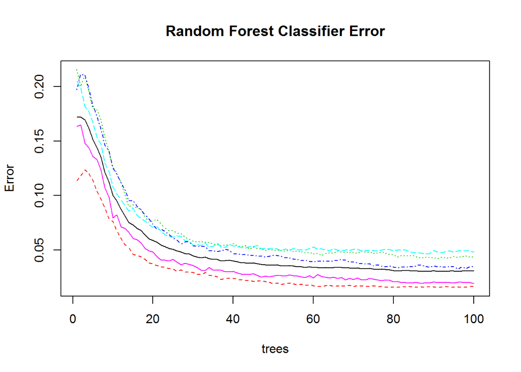

The reason I set the number of trees is mostly based on the above picture. The original number of trees is 500 and it took much longer time to train the model. I also tried building a random forest model without preprocessing the data, the prediction result is very close to the one with pca preprocessing.The fact is true that preprocessing data has little impact on random forest’s model training.

Predict the classes of the test set with random forest classifier.

```r
reducedTest <- predict(prepro, test)
pcaTest <- subset(reducedTest, select = c(PC1:PC34))
predict(fitrf, pcaTest)
```

```
##  1  2  3  4  5  6  7  8  9 10 11 12 13 14 15 16 17 18 19 20
##  B  A  B  A  A  E  D  B  A  A  B  C  B  A  E  E  A  B  B  B
## Levels: A B C D E
```

Predict the classes of test set with svm classifier.

```r
predict(fitsvm, pcaTest)
```

```
##  1  2  3  4  5  6  7  8  9 10 11 12 13 14 15 16 17 18 19 20
##  A  A  C  A  A  E  D  B  A  A  A  C  B  A  E  E  A  B  B  B
## Levels: A B C D E
```

### Conclusions

With the data set generated from multiple measuring instruments, we can accurately predict how well a person is preforming an excercise using a relatively simple machine learning model.During my experiment, the svm model has lower accuracy in this case and it relies on the data preprocessing.